# ml_midterm

## Machine Learning Coursework (Part 1)

For the coursework, please make sure to implement your own code and not use libraries (except where explicitly asked). You will need to present your own code that performs nested cross-validation and the k-nearest neighbour algorithm, build confusion matrices, and estimate distances between data samples.

The purpose of this coursework is to help you:

- Get familiar with **common python modules / functions** used for ML in python
- Get practical experience **implementing** ML methods in python
- Get practical experience regarding **parameter selection** for ML methods
- Get practical experience on **evaluating** ML methods and applying cross-validation

Notes:

- don't use libraries that implement kNN or cross-validation. We want to see your code!
- Remember to comment all of your code (see here for tips: https://stackabuse.com/commenting-python-code/). You can also make use of Jupyter Markdown, where appropriate, to improve the layout of your code and documentation.
- Please add docstrings to all of your functions (so that users can get information on inputs/outputs and what each function does by typing SHIFT+TAB over the function name. For more detail on python docstrings, see here: https://numpydoc.readthedocs.io/en/latest/format.html)
- When a question allows a free-form answer (e.g. what do you observe?), create a new markdown cell below and answer the question in the notebook.
- Always save your notebook when you are done (this is not automatic)!
- Upload your completed notebook using the VLE

Plagiarism: please make sure that the material you submit has been created by you. Any sources you use for code should be properly referenced. Your code will be checked for plagiarism using appropriate software.

### Marking

The grades in this coursework are allocated approximately as follows:

|  | mark |
| --- | --- |
| Data exploration (+ 2 questions) | 10 |
| Code, docu. & comments (KNN + Evaluation + NCV) | 10 |
| Results (KNN folds + Summary + Confusion matrices) | 10 |
| Final questions: | 10 |
| Overall quality & use of Markdown | 10 |
| Total available | **50** |

## 1. Exploratory Data Analysis

In this coursework we are going to be working with the **Wine** dataset. This is a 178 sample dataset that categorises 3 different types of Italian wine using 13 different features. The code below loads the Wine dataset and selects a subset of features for you to work with.

```python
# set matplotlib backend to inline
%matplotlib inline

# import modules
from sklearn import datasets
import numpy as np
import matplotlib.pyplot as plt
import pandas as pd

# load data
wine=datasets.load_wine()
#print(wine.DESCR)

# this dataset has 13 features, we will only choose a subset of these
df_wine = pd.DataFrame(wine.data, columns = wine.feature_names )
selected_features = ['alcohol','flavanoids','color_intensity','ash']

# extract the data as numpy arrays of features, X, and target, y
X = df_wine[selected_features].values
y = wine.target
```

### 1.1. Visualising the data

The first part of tackling any ML problem is visualising the data in order to understand some of the properties of the problem at hand. When there are only a small number of classes and features, it is possible to use scatter plots to visualise interactions between different pairings of features.

The following image shows what such a visualisation might look like on the Iris dataset that you worked on during the Topic exercises.

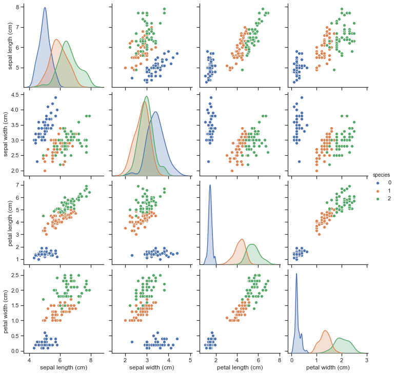

Your first task is to recreate a similar grid for the **Wine** dataset, with each off-diagonal subplot showing the interaction between two features, and each of the classes represented as a different colour. The on-diagonal subplots (representing a single feature) should show a distribution (or histogram) for that feature.

You should create a function that, given data X and labels y, plots this grid. The function should be invoked something like this:

```
myplotGrid(X,y,...)
```

where X is your training data and y are the labels (you may also supply additional optional arguments). You can use an appropriate library to help you create the visualisation. You might want to code it yourself using matplotlib functions scatter and hist - however, this is not strictly necessary here, so try not spend too much time on this.

```python
import seaborn as sns

def plot_graph_grid(X, y, legend_labels):
    """
    plots a grid of scatter plots and KDE plots for the given data X and labels y

    Parameters:
        X : the feature data
        y : the target labels
        legend_labels : the legend labels corresponding to the target labels

    Returns:
        nothing
    """
    fig, ax = plt.subplots(4, 4, figsize=(12, 12), sharex='col')

    for i, feature in enumerate(selected_features):
        for j, other_feature in enumerate(selected_features):
            # plot scatter plots for all combinations of features
            if feature != other_feature:
                for label in np.unique(y):
                    ax[i, j].scatter(X[y == label, selected_features.index(other_feature)], X[y == label, selected_features.index(feature)], label=legend_labels[label], edgecolor='white')
                    # remove tick labels
                    ax[i, j].tick_params(axis='both', which='both', labelbottom=False, labelleft=True)
            else:
                # plot kde plots for the same feature
                for label in np.unique(y):
                    # only show x label for the bottom row and y label for the left column
                    if i == 0:
                        sns.kdeplot(X[y == label, selected_features.index(feature)], ax=ax[i, j], label=legend_labels[label], alpha=0.3, fill=True).set(xlabel='', ylabel=feature)
                    elif j == 3:
                        sns.kdeplot(X[y == label, selected_features.index(feature)], ax=ax[i, j], label=legend_labels[label], alpha=0.3, fill=True).set(xlabel=feature, ylabel='')
                    else:
                        sns.kdeplot(X[y == label, selected_features.index(feature)], ax=ax[i, j], label=legend_labels[label], alpha=0.3, fill=True).set(xlabel='', ylabel='')
                    ax[i, j].tick_params(axis='both', which='both', labelbottom=False, labelleft=False)

    # set x and y labels for the scatter plots
    for i in range(len(selected_features)):
        ax[3, i].set_xlabel(selected_features[i])
        ax[i, 0].set_ylabel(selected_features[i])
        ax[i, 0].tick_params(axis='y', labelleft=True, labelbottom=False)
        ax[3, i].tick_params(axis='x', labelbottom=True, labelleft=False)

    # show tick values on all axes
    for ax_row in ax:
        for ax_elem in ax_row:
            ax_elem.tick_params(axis='both', which='both', labelleft=True, labelbottom=True)

    # set the legend for all plots
    ax[0, 3].legend(loc='upper left', bbox_to_anchor=(1.05, 1))
    plt.tight_layout()
    plt.show()
```

```python
df_wine.head()
```

|  | alcohol | malic_acid | ash | alcalinity_of_ash | magnesium | total_phenols | flavanoids | nonflavanoid_phenols | proanthocyanins | color_intensity | hue | od280/od315_of_diluted_wines | proline |
| --- | --- | --- | --- | --- | --- | --- | --- | --- | --- | --- | --- | --- | --- |
| 0 | 14.23 | 1.71 | 2.43 | 15.6 | 127.0 | 2.80 | 3.06 | 0.28 | 2.29 | 5.64 | 1.04 | 3.92 | 1065.0 |
| 1 | 13.20 | 1.78 | 2.14 | 11.2 | 100.0 | 2.65 | 2.76 | 0.26 | 1.28 | 4.38 | 1.05 | 3.40 | 1050.0 |
| 2 | 13.16 | 2.36 | 2.67 | 18.6 | 101.0 | 2.80 | 3.24 | 0.30 | 2.81 | 5.68 | 1.03 | 3.17 | 1185.0 |
| 3 | 14.37 | 1.95 | 2.50 | 16.8 | 113.0 | 3.85 | 3.49 | 0.24 | 2.18 | 7.80 | 0.86 | 3.45 | 1480.0 |
| 4 | 13.24 | 2.59 | 2.87 | 21.0 | 118.0 | 2.80 | 2.69 | 0.39 | 1.82 | 4.32 | 1.04 | 2.93 | 735.0 |

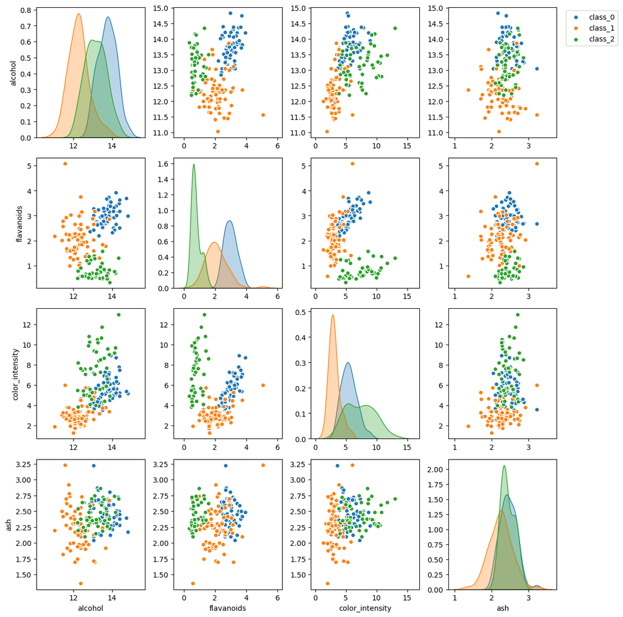

```python
# run the plotting function
plot_graph_grid(X, y, wine.target_names)
```

### 1.2. Exploratory Data Analysis under noise

When data are collected under real-world settings they usually contain some amount of noise that makes classification more challenging. In the cell below, invoke your exploratory data analysis function above on a noisy version of your data X.

Try to perturb your data with some Gaussian noise,

```
# initialize random seed to replicate results over different runs
mySeed = 12345
np.random.seed(mySeed)
XN=X+np.random.normal(0,0.6,X.shape)
```

and then invoke

```
myplotGrid(XN,y)
```

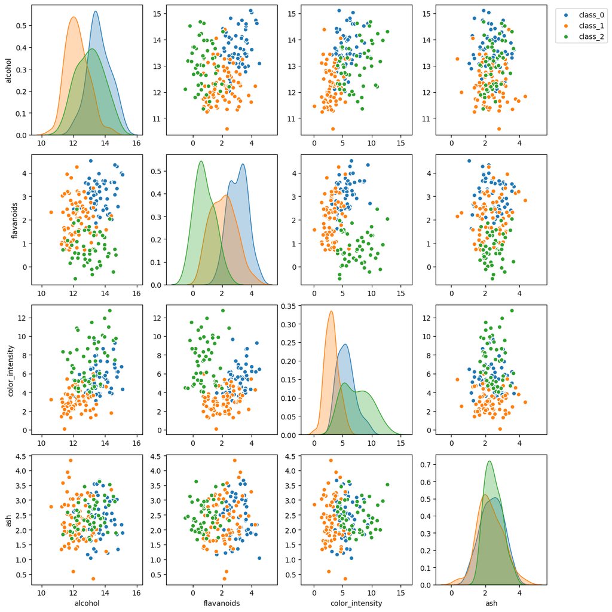

```python
# noise code
mySeed = 12345
np.random.seed(mySeed)
XN=X+np.random.normal(0,0.6,X.shape)

plot_graph_grid(XN, y, wine.target_names)
```

### Q1. Exploratory data analysis

Based on your exploratory analysis, if you were to build a classifier using only two of the available features, which ones would you choose and why? Answer as fully as you can.

answer: If I had to choose 2 features to classify the wines, by looking at my plots I would choose color intensity and flavanoids. Looking at the color intenisty vs flavanoids plot it seems to have the clearest seperation of the 3 classes compared to the other feature comparison plots. The histograms also show the least overlap for color intensity and flavanoids, so those 2 should yield the most accurate classifcations

### Q2. Data with noise

What do you observe by plotting the data without noise compared to plotting with added Gaussian noise?

answer: I notice with the Gaussian noise the scatter plots seems to be more dispersed and the different classes are more mixed together rather than seperate compared to true values before. Also I see that Histogram plots are slightly wider and have less sharp and precise curves as it did before.

## 2. Implementing kNN

In the cell below, develop your own code for performing k-Nearest Neighbour classification. You may use the scikit-learn k-NN implementation from the labs as a guide - and as a way of verifying your results - but it is important that your implementation does not use any libraries other than the basic numpy and matplotlib functions.

Define a function that performs k-NN given a set of data. Your function should be invoked similary to:

```
    y_ = mykNN(X,y,X_,options)
```

where X is your training data, y is your training outputs, X_ are your testing data and y_ are your predicted outputs for X_. The options argument (can be a list or a set of separate arguments depending on how you choose to implement the function) should at least contain the number of neighbours to consider as well as the distance function employed.

Hint: it helps to break the problem into various sub-problems, implemented as helper function. For example, you might want to implement separate function(s) for calculating the distances between two vectors. And another function that uncovers the nearest neighbour(s) to a given vector.

```python
# helper code

def split_data(X,y):
    """
    splits the given data into training and test sets

    Parameters:
        X : the feature data
        y : the target labels

    Returns:
        X_train : the training feature data
        X_test : the test feature data
        y_train : the training target labels
        y_test : the test target labels
    """
    # set the random seed
    np.random.seed(mySeed)

    samples = len(X)

    indices = np.random.permutation(samples)

    # get the number of training samples (70% of the data)
    train_samples = int(np.ceil(samples * 0.7))

    X_train = X[indices[:train_samples]]
    y_train = y[indices[:train_samples]]

    X_test = X[indices[train_samples:]]
    y_test = y[indices[train_samples:]]


    return X_train, X_test, y_train, y_test

def distance_between_vectors(x1, x2):
    """
    calculates the Euclidean distance between two vectors

    Parameters:
        x1 : the first vector
        x2 : the second vector

    Returns:
        the Euclidean distance between the two vectors
    """
    distance = np.sqrt(np.sum((x1 - x2)**2))
    return distance

def compare_distances(x, X_train, y_train, options):
    """
    calculates the Euclidean distance between a vector and all vectors in a dataset and returns the shortest distances

    Parameters:
        x : the vector to compare distances to
        X_train : the feature data
        y_train : the target labels
        options : the number of shortest distances to return

    Returns:
        a list of the shortest distances and their labels
    """

    list_of_shortest_distances = []
    for i in range(len(X_train)):
        distance = distance_between_vectors(x, X_train[i])
        if len(list_of_shortest_distances) < options:
            list_of_shortest_distances.append((distance, y_train[i]))
        else:
            list_of_shortest_distances.sort(reverse=True)
            if distance < list_of_shortest_distances[0][0]:
                list_of_shortest_distances[0] = (distance, y_train[i])
    return list_of_shortest_distances
```

```python
def mykNN(X,y,X_,options):
    """
    Classifies the given data using the k-Nearest Neighbors algorithm.

    Parameters:
        X : The training feature data.
        y : The training target labels.
        X_ : The test feature data.
        options : The number of neighbors to consider.

    Returns:
        y_ : The predicted target labels.

    """
    y_ = []
    for unknown in X_:
        closest = compare_distances(unknown, X, y, options)
        for i in range(len(closest)):
            closest[i] = closest[i][1]
        #find most common value and if there is a tie, choose the first one
        unique, counts = np.unique(closest, return_counts=True)
        most_occuring = unique[np.argmax(counts)]
        y_.append(most_occuring)
    return y_
```

```python
from sklearn.metrics import accuracy_score
X_train, X_test, y_train, y_test = split_data(XN, y)

y_pred = mykNN(X_train, y_train, X_test, 3)

print("Accuracy:", accuracy_score(y_test, y_pred))
```

```
Accuracy: 0.8679245283018868
```

## 3. Classifier evaluation

In the cell below, implement your own classifier evaluation code. This should include some way of calculating confusion matrices, as well as common metrics like accuracy.

Write some additional code that lets you display the output of your confusion matrices in a useful and easy-to-read manner.

You might want to test your functions on some test data, and compare the results to the sklearn library versions.

```python
# confusion matrix, accuracy, precision, recall, etc.

def confusion_matrix(y_true, y_pred, labels):
    """
    calculates the confusion matrix for the given data

    Parameters:
        y_true : the true target labels
        y_pred : the predicted target labels
        labels : the labels to use for the confusion matrix

    Returns:
        cm : the confusion matrix
    """
    # initialize the confusion matrix
    cm = np.zeros((len(labels), len(labels)))

    # populate the confusion matrix
    for i in range(len(y_true)):
        cm[y_true[i]][y_pred[i]] += 1

    return cm

def draw_confusion_matrix(cm, labels):
    """
    draws the confusion matrix via print statements

    Parameters:
        cm : the confusion matrix
        labels : the labels to use for the confusion matrix

    Returns:
        nothing
    """
    print("\tConfusion Matrix")
    print("T\P", end="\t")
    for label in labels:
        print(label, end="\t")
    print()
    for i in range(len(cm)):
        print(labels[i], end="\t")
        for j in range(len(cm[i])):
            print(cm[i][j], end="\t")
        print()



def calc_accuracy(y_true, y_pred):
    """
    calculates the accuracy of the given data

    Parameters:
        y_true : the true target labels
        y_pred : the predicted target labels

    Returns:
        the accuracy of the given data
    """
    # create the confusion matrix
    cm = confusion_matrix(y_true, y_pred, np.unique(y_true))

    # calculate the accuracy
    correct = cm[0][0] + cm[1][1] + cm[2][2]
    total = np.sum(cm)
    accuracy = correct / total

    return accuracy

def recall(y_true, y_pred, label):
    """
    calculates the recall of the given data for a given label

    Parameters:
        y_true : the true target labels
        y_pred : the predicted target labels
        label : the label to calculate the recall for

    Returns:
        the recall of the given data for the given label
    """
    # create the confusion matrix
    cm = confusion_matrix(y_true, y_pred, np.unique(y_true))

    # calculate the recall
    true_positives = cm[label][label]
    false_negatives = cm[label][0] + cm[label][1] + cm[label][2] - true_positives
    recall = true_positives / (true_positives + false_negatives)

    return recall

def precision(y_true, y_pred, label):
    """
    calculates the precision of the given data

    Parameters:
        y_true : the true target labels
        y_pred : the predicted target labels
        label : the label to calculate the precision for

    Returns:
        the precision of the given data
    """
    # create the confusion matrix
    cm = confusion_matrix(y_true, y_pred, np.unique(y_true))

    # calculate the precision
    true_positives = cm[label][label]
    false_positives = cm[0][label] + cm[1][label] + cm[2][label] - true_positives
    precision = true_positives / (true_positives + false_positives)

    return precision
```

```python
# test evaluation code

print("y_test:", y_test)
print("y_pred:", y_pred)
print()
cm = confusion_matrix(y_test, y_pred, np.unique(y_test))
draw_confusion_matrix(cm, np.unique(y_test))
print()
print("Accuracy:", calc_accuracy(y_test, y_pred))
print("Recall:", recall(y_test, y_pred, 0))
print("Precision:", precision(y_test, y_pred, 0))
print()

#compare to sklearn
from sklearn.neighbors import KNeighborsClassifier
sk_classifier = KNeighborsClassifier(n_neighbors=3)
sk_classifier.fit(X_train, y_train)
y_pred_sk = sk_classifier.predict(X_test)
print("y_pred_sk:", y_pred_sk)
print()
cm = confusion_matrix(y_test, y_pred_sk, np.unique(y_test))
draw_confusion_matrix(cm, np.unique(y_test))
print()
print("SK_Accuracy:", calc_accuracy(y_test, y_pred_sk))
print("SK_Recall:", recall(y_test, y_pred_sk, 0))
print("SK_Precision:", precision(y_test, y_pred_sk, 0))
print()
```

```
y_test: [1 0 0 1 2 2 1 0 1 2 0 2 2 1 2 1 1 1 2 2 1 2 1 0 1 2 1 0 2 0 0 0 1 2 1 0 1
 2 1 1 2 1 1 1 0 2 0 1 1 2 2 1 0]
y_pred: [1, 0, 0, 1, 2, 2, 1, 0, 0, 2, 0, 2, 2, 1, 2, 1, 1, 1, 2, 0, 0, 2, 1, 0, 1, 1, 1, 0, 2, 0, 0, 0, 1, 0, 1, 0, 1, 2, 1, 1, 2, 1, 1, 1, 0, 2, 0, 1, 0, 2, 2, 1, 1]

	Confusion Matrix
T\P	0	1	2
0	12.0	1.0	0.0
1	3.0	20.0	0.0
2	2.0	1.0	14.0

Accuracy: 0.8679245283018868
Recall: 0.9230769230769231
Precision: 0.7058823529411765

y_pred_sk: [1 0 0 1 2 2 1 0 0 2 0 2 2 1 2 1 1 1 2 0 0 2 1 0 1 1 1 0 2 0 0 0 1 0 1 0 1
 2 1 1 2 1 1 1 0 2 0 1 0 2 2 1 1]

	Confusion Matrix
T\P	0	1	2
0	12.0	1.0	0.0
1	3.0	20.0	0.0
2	2.0	1.0	14.0

SK_Accuracy: 0.8679245283018868
SK_Recall: 0.9230769230769231
SK_Precision: 0.7058823529411765
```

## 4. Nested Cross-validation using your implementation of KNN

In the cell below, develop your own code for performing 5-fold nested cross-validation along with your implemenation of k-NN above. You must write your own code -- the scikit-learn module may only be used for verification purposes.

Your code for nested cross-validation should invoke your kNN function (see above). You cross validation function should be invoked similary to:

```
accuracies_fold = myNestedCrossVal(X,y,5,list(range(1,11)),['euclidean','manhattan'],mySeed)
```

where X is your data matrix (containing all samples and features for each sample), 5 is the number of folds, y are your known output labels, `list(range(1,11)` evaluates the neighbour parameter from 1 to 10, and `['euclidean','manhattan',...]` evaluates the distances on the validation sets. mySeed is simply a random seed to enable us to replicate your results.

**Notes:**

- you should perform nested cross-validation on **both** your original data X, as well as the data pertrubed by noise as shown in the cells above (XN)
- you should evaluate **at least** two distance functions
- you should evaluate number of neighbours from 1 to 10
- your function should return a list of accuracies per fold
- for each **fold**, your function should print:
  - the accuracy per distinct set of parameters on the validation set
  - the best set of parameters for the fold after validation
  - the confusion matrix per fold (on the testing set)

```python
#Make manhattan distance function
def manhattan_distance(x1, x2):
    """
    calculates the manhattan distance between two points

    Parameters:
        x1 : the first point
        x2 : the second point

    Returns:
        the manhattan distance between the two points
    """
    distance = np.sum(np.abs(x1 - x2))
    return distance


#redo compare distance function to use manhattan distance

def compare_distances_manhattan(x, X_train, y_train, options):
    """
    calculates the Manhattan distance between a vector and all vectors in a dataset and returns the shortest distances

    Parameters:
        x : the vector to compare distances to
        X_train : the feature data
        y_train : the target labels
        options : the number of shortest distances to return

    Returns:
        a list of the shortest distances and their labels
    """

    list_of_shortest_distances = []
    for i in range(len(X_train)):
        distance = manhattan_distance(x, X_train[i])
        if len(list_of_shortest_distances) < options:
            list_of_shortest_distances.append((distance, y_train[i]))
        else:
            list_of_shortest_distances.sort(reverse=True)
            if distance < list_of_shortest_distances[0][0]:
                list_of_shortest_distances[0] = (distance, y_train[i])
    return list_of_shortest_distances

#redo mykNN to use manhattan distance

def mykNNManhattan(X, y, X_, options):
    """
    Classifies the given data using the k-Nearest Neighbors algorithm.

    Parameters:
        X : The training feature data.
        y : The training target labels.
        X_ : The test feature data.
        options : The number of neighbors to consider.

    Returns:
        y_ : The predicted target labels.

    """
    y_ = []
    for unknown in X_:
        closest = compare_distances_manhattan(unknown, X, y, options)
        for i in range(len(closest)):
            closest[i] = closest[i][1]
        #find most common value and if there is a tie, choose the first one
        unique, counts = np.unique(closest, return_counts=True)
        most_occuring = unique[np.argmax(counts)]
        y_.append(most_occuring)
    return y_

# myNestedCrossVal code

def myNestedCrossVal(X, y, k, neighbor_amount, methods, seed):
    """
    performs nested cross validation on the given data and prints the results

    Parameters:
        X : the feature data
        y : the target labels
        k : the number of folds
        neighbor_amount : the number of neighbors
        methods : the distance methods to use
        seed : the seed to use for the random number generator

    Returns:
        all_accuracies : a list of the accuracies for each fold

    """
    np.random.seed(seed)
    samples = len(X)
    indices = np.random.permutation(samples)

    # Shuffle the data
    X = X[indices]
    y = y[indices]

    # Split the data into k folds
    X_folds = np.array_split(X, k)
    y_folds = np.array_split(y, k)

    all_accuracies = []
    all_cm = []

    for i in range(k):
        fold_accuracies = []

        # Create the training and testing data
        X_train = np.concatenate(X_folds[:i] + X_folds[i+1:])
        y_train = np.concatenate(y_folds[:i] + y_folds[i+1:])
        X_test = X_folds[i]
        y_test = y_folds[i]

        best_method = ""
        best_neighbors = 0
        best_accuracy = 0

        for method in methods:
            # Split the training data into k folds
            X_train_folds = np.array_split(X_train, k)
            y_train_folds = np.array_split(y_train, k)

            # Create the training and validation data
            X_train_inner = np.concatenate(X_train_folds[:0] + X_train_folds[1:])
            y_train_inner = np.concatenate(y_train_folds[:0] + y_train_folds[1:])
            X_val_inner = X_train_folds[0]
            y_val_inner = y_train_folds[0]

            if method == "euclidean":
                for neighbors in neighbor_amount:
                    # Use my old code to create the model since it uses Euclidean distance
                    y_pred_euc = mykNN(X_train_inner, y_train_inner, X_val_inner, neighbors)
                    # Calculate the accuracy
                    accuracy = calc_accuracy(y_val_inner, y_pred_euc)
                    # Check if this is the best accuracy in the fold
                    if accuracy > best_accuracy:
                        best_accuracy = accuracy
                        best_neighbors = neighbors
                        best_method = method
                    # Add the accuracy to the list
                    fold_accuracies.append(accuracy)
                    print(f"Fold {i+1} - {method} - Neighbors={neighbors}- Accuracy:", accuracy)
            elif method == "manhattan":
                for neighbors in neighbor_amount:
                    # Use my Manhattan code to create the model
                    y_pred_man = mykNNManhattan(X_train, y_train, X_test, neighbors)
                    # Calculate the accuracy
                    accuracy = calc_accuracy(y_test, y_pred_man)
                    # Check if this is the best accuracy in the fold
                    if accuracy > best_accuracy:
                        best_accuracy = accuracy
                        best_neighbors = neighbors
                        best_method = method
                    # Add the accuracy to the list
                    fold_accuracies.append(accuracy)
                    print(f"Fold {i+1} - {method} - Neighbors={neighbors} - Accuracy:", accuracy)
        print()
        print(f"Best Accuracy in Fold {i+1}:", best_accuracy)
        print(f"Best Neighbors in Fold {i+1}:", best_neighbors)
        print(f"Best Method in Fold {i+1}:", best_method)
        print()

        if best_method == "euclidean":
            y_pred = mykNN(X_train, y_train, X_test, best_neighbors)
            accuracy = calc_accuracy(y_test, y_pred)
            all_accuracies.append(accuracy)
        elif best_method == "manhattan":
            y_pred = mykNNManhattan(X_train, y_train, X_test, best_neighbors)
            accuracy = calc_accuracy(y_test, y_pred)
            all_accuracies.append(accuracy)

        # Calculate the accuracy
        accuracy = accuracy_score(y_test, y_pred)
        cm = confusion_matrix(y_test, y_pred, np.unique(y))
        print(end="\t")
        print(f"Fold {i+1}")
        draw_confusion_matrix(cm, np.unique(y))
        all_cm.append(cm)
        print()
        print()

    print("OVERALL SUMMARY CONFUSION MATRIX")

    #combine all folds into one confusion matrix
    overall_cm = np.zeros((len(np.unique(y)), len(np.unique(y))))
    for i in range(len(all_accuracies)):
        overall_cm += all_cm[i]
    overall_cm = overall_cm.astype(int)
    draw_confusion_matrix(overall_cm, np.unique(y))
    print()

    return all_accuracies
```

```python
# evaluate clean data code
myNestedCrossVal(X, y, 5, list(range(1,11)), ["euclidean", "manhattan"], mySeed)
```

```
Fold 1 - euclidean - Neighbors=1- Accuracy: 0.896551724137931
Fold 1 - euclidean - Neighbors=2- Accuracy: 0.896551724137931
Fold 1 - euclidean - Neighbors=3- Accuracy: 0.896551724137931
Fold 1 - euclidean - Neighbors=4- Accuracy: 0.896551724137931
Fold 1 - euclidean - Neighbors=5- Accuracy: 0.9310344827586207
Fold 1 - euclidean - Neighbors=6- Accuracy: 0.896551724137931
Fold 1 - euclidean - Neighbors=7- Accuracy: 0.9310344827586207
Fold 1 - euclidean - Neighbors=8- Accuracy: 0.9310344827586207
Fold 1 - euclidean - Neighbors=9- Accuracy: 0.9310344827586207
Fold 1 - euclidean - Neighbors=10- Accuracy: 0.896551724137931
Fold 1 - manhattan - Neighbors=1 - Accuracy: 0.9444444444444444
Fold 1 - manhattan - Neighbors=2 - Accuracy: 0.9722222222222222
Fold 1 - manhattan - Neighbors=3 - Accuracy: 0.9722222222222222
Fold 1 - manhattan - Neighbors=4 - Accuracy: 0.9722222222222222
Fold 1 - manhattan - Neighbors=5 - Accuracy: 0.9722222222222222
Fold 1 - manhattan - Neighbors=6 - Accuracy: 0.9722222222222222
Fold 1 - manhattan - Neighbors=7 - Accuracy: 0.9722222222222222
Fold 1 - manhattan - Neighbors=8 - Accuracy: 0.9722222222222222
Fold 1 - manhattan - Neighbors=9 - Accuracy: 0.9722222222222222
Fold 1 - manhattan - Neighbors=10 - Accuracy: 0.9722222222222222

Best Accuracy in Fold 1: 0.9722222222222222
Best Neighbors in Fold 1: 2
Best Method in Fold 1: manhattan

	Fold 1
	Confusion Matrix
T\P	0	1	2
0	12.0	0.0	0.0
1	0.0	13.0	1.0
2	0.0	0.0	10.0


Fold 2 - euclidean - Neighbors=1- Accuracy: 0.9655172413793104
Fold 2 - euclidean - Neighbors=2- Accuracy: 0.9655172413793104
Fold 2 - euclidean - Neighbors=3- Accuracy: 0.9655172413793104
Fold 2 - euclidean - Neighbors=4- Accuracy: 0.9655172413793104
Fold 2 - euclidean - Neighbors=5- Accuracy: 0.9655172413793104
Fold 2 - euclidean - Neighbors=6- Accuracy: 0.9655172413793104
Fold 2 - euclidean - Neighbors=7- Accuracy: 0.9655172413793104
```

[output cut: 116 more lines]

```

	Fold 5
	Confusion Matrix
T\P	0	1	2
0	9.0	0.0	0.0
1	1.0	14.0	0.0
2	0.0	0.0	11.0


OVERALL SUMMARY CONFUSION MATRIX
	Confusion Matrix
T\P	0	1	2
0	58	1	0
1	5	64	2
2	0	2	46
```

```
[0.9722222222222222,
 0.9166666666666666,
 0.9444444444444444,
 0.9142857142857143,
 0.9714285714285714]
```

```python
# evaluate noisy  data code
myNestedCrossVal(XN, y, 5, list(range(1,11)), ["euclidean", "manhattan"], mySeed)
```

```
Fold 1 - euclidean - Neighbors=1- Accuracy: 0.9310344827586207
Fold 1 - euclidean - Neighbors=2- Accuracy: 0.7931034482758621
Fold 1 - euclidean - Neighbors=3- Accuracy: 0.8275862068965517
Fold 1 - euclidean - Neighbors=4- Accuracy: 0.8275862068965517
Fold 1 - euclidean - Neighbors=5- Accuracy: 0.8620689655172413
Fold 1 - euclidean - Neighbors=6- Accuracy: 0.8620689655172413
Fold 1 - euclidean - Neighbors=7- Accuracy: 0.8275862068965517
Fold 1 - euclidean - Neighbors=8- Accuracy: 0.896551724137931
Fold 1 - euclidean - Neighbors=9- Accuracy: 0.896551724137931
Fold 1 - euclidean - Neighbors=10- Accuracy: 0.8275862068965517
Fold 1 - manhattan - Neighbors=1 - Accuracy: 0.8611111111111112
Fold 1 - manhattan - Neighbors=2 - Accuracy: 0.8333333333333334
Fold 1 - manhattan - Neighbors=3 - Accuracy: 0.9444444444444444
Fold 1 - manhattan - Neighbors=4 - Accuracy: 0.9722222222222222
Fold 1 - manhattan - Neighbors=5 - Accuracy: 0.9444444444444444
Fold 1 - manhattan - Neighbors=6 - Accuracy: 0.9444444444444444
Fold 1 - manhattan - Neighbors=7 - Accuracy: 0.9444444444444444
Fold 1 - manhattan - Neighbors=8 - Accuracy: 0.9722222222222222
Fold 1 - manhattan - Neighbors=9 - Accuracy: 0.9722222222222222
Fold 1 - manhattan - Neighbors=10 - Accuracy: 0.9722222222222222

Best Accuracy in Fold 1: 0.9722222222222222
Best Neighbors in Fold 1: 4
Best Method in Fold 1: manhattan

	Fold 1
	Confusion Matrix
T\P	0	1	2
0	12.0	0.0	0.0
1	0.0	13.0	1.0
2	0.0	0.0	10.0


Fold 2 - euclidean - Neighbors=1- Accuracy: 0.896551724137931
Fold 2 - euclidean - Neighbors=2- Accuracy: 0.7931034482758621
Fold 2 - euclidean - Neighbors=3- Accuracy: 0.9310344827586207
Fold 2 - euclidean - Neighbors=4- Accuracy: 0.896551724137931
Fold 2 - euclidean - Neighbors=5- Accuracy: 0.9310344827586207
Fold 2 - euclidean - Neighbors=6- Accuracy: 0.9310344827586207
Fold 2 - euclidean - Neighbors=7- Accuracy: 0.9310344827586207
```

[output cut: 116 more lines]

```

	Fold 5
	Confusion Matrix
T\P	0	1	2
0	9.0	0.0	0.0
1	1.0	14.0	0.0
2	0.0	0.0	11.0


OVERALL SUMMARY CONFUSION MATRIX
	Confusion Matrix
T\P	0	1	2
0	52	4	3
1	6	63	2
2	0	1	47
```

```
[0.9722222222222222,
 0.8611111111111112,
 0.8611111111111112,
 0.8857142857142857,
 0.9714285714285714]
```

## 5. Summary of results

Using your results from above, fill out the following table using the **clean** data:

[output not shown]

Where **total** is given as an average over all the folds, and $\pm$ the standard deviation.

Now fill out the following table using the **noisy** data:

[output not shown]

### 5.2. Confusion matrix summary

Summarise the overall results of your nested cross validation evaluation of your K-NN algorithm using two summary confusion matrices (one for the noisy data, one for the clean data). You might want to adapt your `myNestedCrossVal` code above to also return a list of confusion matrices.

Use or adapt your evaluation code above to print the two confusion matrices below. Make sure you label the matrix rows and columns. You might also want ot show class-relative precision and recall.

```python
print('CLEAN')
# clean data summary results
myNestedCrossVal(X, y, 5, list(range(1,11)), ["euclidean", "manhattan"], mySeed)
```

```
CLEAN
Fold 1 - euclidean - Neighbors=1- Accuracy: 0.896551724137931
Fold 1 - euclidean - Neighbors=2- Accuracy: 0.896551724137931
Fold 1 - euclidean - Neighbors=3- Accuracy: 0.896551724137931
Fold 1 - euclidean - Neighbors=4- Accuracy: 0.896551724137931
Fold 1 - euclidean - Neighbors=5- Accuracy: 0.9310344827586207
Fold 1 - euclidean - Neighbors=6- Accuracy: 0.896551724137931
Fold 1 - euclidean - Neighbors=7- Accuracy: 0.9310344827586207
Fold 1 - euclidean - Neighbors=8- Accuracy: 0.9310344827586207
Fold 1 - euclidean - Neighbors=9- Accuracy: 0.9310344827586207
Fold 1 - euclidean - Neighbors=10- Accuracy: 0.896551724137931
Fold 1 - manhattan - Neighbors=1 - Accuracy: 0.9444444444444444
Fold 1 - manhattan - Neighbors=2 - Accuracy: 0.9722222222222222
Fold 1 - manhattan - Neighbors=3 - Accuracy: 0.9722222222222222
Fold 1 - manhattan - Neighbors=4 - Accuracy: 0.9722222222222222
Fold 1 - manhattan - Neighbors=5 - Accuracy: 0.9722222222222222
Fold 1 - manhattan - Neighbors=6 - Accuracy: 0.9722222222222222
Fold 1 - manhattan - Neighbors=7 - Accuracy: 0.9722222222222222
Fold 1 - manhattan - Neighbors=8 - Accuracy: 0.9722222222222222
Fold 1 - manhattan - Neighbors=9 - Accuracy: 0.9722222222222222
Fold 1 - manhattan - Neighbors=10 - Accuracy: 0.9722222222222222

Best Accuracy in Fold 1: 0.9722222222222222
Best Neighbors in Fold 1: 2
Best Method in Fold 1: manhattan

	Fold 1
	Confusion Matrix
T\P	0	1	2
0	12.0	0.0	0.0
1	0.0	13.0	1.0
2	0.0	0.0	10.0


Fold 2 - euclidean - Neighbors=1- Accuracy: 0.9655172413793104
Fold 2 - euclidean - Neighbors=2- Accuracy: 0.9655172413793104
Fold 2 - euclidean - Neighbors=3- Accuracy: 0.9655172413793104
Fold 2 - euclidean - Neighbors=4- Accuracy: 0.9655172413793104
Fold 2 - euclidean - Neighbors=5- Accuracy: 0.9655172413793104
Fold 2 - euclidean - Neighbors=6- Accuracy: 0.9655172413793104
```

[output cut: 117 more lines]

```

	Fold 5
	Confusion Matrix
T\P	0	1	2
0	9.0	0.0	0.0
1	1.0	14.0	0.0
2	0.0	0.0	11.0


OVERALL SUMMARY CONFUSION MATRIX
	Confusion Matrix
T\P	0	1	2
0	58	1	0
1	5	64	2
2	0	2	46
```

```
[0.9722222222222222,
 0.9166666666666666,
 0.9444444444444444,
 0.9142857142857143,
 0.9714285714285714]
```

```python
print('NOISY')
# noisy data summary results
myNestedCrossVal(XN, y, 5, list(range(1,11)), ["euclidean", "manhattan"], mySeed)
```

```
NOISY
Fold 1 - euclidean - Neighbors=1- Accuracy: 0.9310344827586207
Fold 1 - euclidean - Neighbors=2- Accuracy: 0.7931034482758621
Fold 1 - euclidean - Neighbors=3- Accuracy: 0.8275862068965517
Fold 1 - euclidean - Neighbors=4- Accuracy: 0.8275862068965517
Fold 1 - euclidean - Neighbors=5- Accuracy: 0.8620689655172413
Fold 1 - euclidean - Neighbors=6- Accuracy: 0.8620689655172413
Fold 1 - euclidean - Neighbors=7- Accuracy: 0.8275862068965517
Fold 1 - euclidean - Neighbors=8- Accuracy: 0.896551724137931
Fold 1 - euclidean - Neighbors=9- Accuracy: 0.896551724137931
Fold 1 - euclidean - Neighbors=10- Accuracy: 0.8275862068965517
Fold 1 - manhattan - Neighbors=1 - Accuracy: 0.8611111111111112
Fold 1 - manhattan - Neighbors=2 - Accuracy: 0.8333333333333334
Fold 1 - manhattan - Neighbors=3 - Accuracy: 0.9444444444444444
Fold 1 - manhattan - Neighbors=4 - Accuracy: 0.9722222222222222
Fold 1 - manhattan - Neighbors=5 - Accuracy: 0.9444444444444444
Fold 1 - manhattan - Neighbors=6 - Accuracy: 0.9444444444444444
Fold 1 - manhattan - Neighbors=7 - Accuracy: 0.9444444444444444
Fold 1 - manhattan - Neighbors=8 - Accuracy: 0.9722222222222222
Fold 1 - manhattan - Neighbors=9 - Accuracy: 0.9722222222222222
Fold 1 - manhattan - Neighbors=10 - Accuracy: 0.9722222222222222

Best Accuracy in Fold 1: 0.9722222222222222
Best Neighbors in Fold 1: 4
Best Method in Fold 1: manhattan

	Fold 1
	Confusion Matrix
T\P	0	1	2
0	12.0	0.0	0.0
1	0.0	13.0	1.0
2	0.0	0.0	10.0


Fold 2 - euclidean - Neighbors=1- Accuracy: 0.896551724137931
Fold 2 - euclidean - Neighbors=2- Accuracy: 0.7931034482758621
Fold 2 - euclidean - Neighbors=3- Accuracy: 0.9310344827586207
Fold 2 - euclidean - Neighbors=4- Accuracy: 0.896551724137931
Fold 2 - euclidean - Neighbors=5- Accuracy: 0.9310344827586207
Fold 2 - euclidean - Neighbors=6- Accuracy: 0.9310344827586207
```

[output cut: 117 more lines]

```

	Fold 5
	Confusion Matrix
T\P	0	1	2
0	9.0	0.0	0.0
1	1.0	14.0	0.0
2	0.0	0.0	11.0


OVERALL SUMMARY CONFUSION MATRIX
	Confusion Matrix
T\P	0	1	2
0	52	4	3
1	6	63	2
2	0	1	47
```

```
[0.9722222222222222,
 0.8611111111111112,
 0.8611111111111112,
 0.8857142857142857,
 0.9714285714285714]
```

## 6. More questions

Now answer the following questions as fully as you can. The answers should be based on your implementation above. Write your answers in the Markdown cells below each question.

### Q3. Influence of noise

Do the best parameters change when noise is added to the data? Can you say that one parameter choice is better regardless of the data used?

### Q4. Tie break

Assume that you have selected the number of neighbours to be an even number, e.g., 2. For one of the neighbours, the suggested class is 1, and for the other neighbour the suggested class is 2. How would you break the tie? Write example pseudocode that does this.

Answer: To break the tie between 2 neighbours of different classes, I would label the unknown X-value as the class of the neighbour that is the nearest in distance, where distance is calculate in whichever method we were using. If by chance the distances were exactly the same I would just label the value as the class of the first neighbour I compared it to.

```
function breakTie(X ,neighbour1, neighbour2) {
    if (distance(X, neighbour1) < distance(X, neighbour2)) {
        return neighbour1.class;
    } else if (distance(X, neighbour1) > distance(X, neighbour2)) {
        return neighbour2.class;
    } else {
        return neighbour1.class;
    }
}
```

### Q5. Beyond Wine

If you were to run your k-nn algorithm on a new dataset (e.g., the breast cancer dataset, or Iris), what considerations would you need to take into consideration? Outline any changes that might be needed to your code.

Answer: I think when working with a dataset such as breastcancer and the goal is to classify the data as either positive for breastcancer or negative for breastcancer, you would really need to consider the fact that falsely classifying someone with breast cancer if they are in fact cancer free is a major issue that should definitely be a high priority in preventing. So that would mean I would need to fine tune my knn algorithm to reduce the amount of false positives as much as possible even if it meant reducing the accuracy of my model. Another thing to take into consideration for a different data set is how it is split, If I were to use my current algorithm on a dataset that has 90% cancer free rows and 10% rows that are labeled for breast cancer, my algorithm could actually do a bad job actually being able to classify breast cancer in real world scenarios, since it may just labeling everything as cancer free and that would be a 90% accuracy for my data set, giving a false impression of a good algorithm. So in that case I would also take care to focus on precision and recall results, and worry less about accuracy. The reverse could also be true where the dataset would be 50/50 for cancerous and non-cancerous rows, this would mean training my data on this would lead to situations in the real world where breast cancer is a lot less likely but since my model is trained with 50/50 data it would likely jump the gun on classifying a real world case as breast cancer when it is in fact not. To prevent this in my algorithm, I would test the model on different splits of data, finding a good middle ground and as mentioned before focus more on precision, recall results and preventing false positives as much as I can. In more detail these changes would include viewing the recall, precision and false positive values for each fold and inner fold and instead of choosing the highest accuracy I would choose the highest precision, or maybe a good middleground between the 2.